# NAME-PAPU SWAIN

## OBJECTIVE-

1.NIDDK (National Institute of Diabetes and Digestive and Kidney Diseases) research creates knowledge about and treatments for the most chronic, costly, and consequential diseases.

2.The dataset used in this project is originally from NIDDK. The objective is to predict whether or not a patient has diabetes, based on certain diagnostic measurements included in the dataset.

3.Build a model to accurately predict whether the patients in the dataset have diabetes or not.

## Project Task: Week 1(Data Exploration)

```python
import pandas as pd
import numpy as np
import matplotlib.pyplot as plt
import seaborn as sns
%matplotlib inline
import warnings
warnings.filterwarnings("ignore")
```

```python
df=pd.read_csv("health care diabetes.csv")
df.head()
```

|  | Pregnancies | Glucose | BloodPressure | SkinThickness | Insulin | BMI | DiabetesPedigreeFunction | Age | Outcome |
| --- | --- | --- | --- | --- | --- | --- | --- | --- | --- |
| 0 | 6 | 148 | 72 | 35 | 0 | 33.6 | 0.627 | 50 | 1 |
| 1 | 1 | 85 | 66 | 29 | 0 | 26.6 | 0.351 | 31 | 0 |
| 2 | 8 | 183 | 64 | 0 | 0 | 23.3 | 0.672 | 32 | 1 |
| 3 | 1 | 89 | 66 | 23 | 94 | 28.1 | 0.167 | 21 | 0 |
| 4 | 0 | 137 | 40 | 35 | 168 | 43.1 | 2.288 | 33 | 1 |

```python
df.info()
```

```
<class 'pandas.core.frame.DataFrame'>
RangeIndex: 768 entries, 0 to 767
Data columns (total 9 columns):
 #   Column                    Non-Null Count  Dtype
---  ------                    --------------  -----
 0   Pregnancies               768 non-null    int64
 1   Glucose                   768 non-null    int64
 2   BloodPressure             768 non-null    int64
 3   SkinThickness             768 non-null    int64
 4   Insulin                   768 non-null    int64
 5   BMI                       768 non-null    float64
 6   DiabetesPedigreeFunction  768 non-null    float64
 7   Age                       768 non-null    int64
 8   Outcome                   768 non-null    int64
dtypes: float64(2), int64(7)
memory usage: 54.1 KB
```

```python
df.describe()
```

|  | Pregnancies | Glucose | BloodPressure | SkinThickness | Insulin | BMI | DiabetesPedigreeFunction | Age | Outcome |
| --- | --- | --- | --- | --- | --- | --- | --- | --- | --- |
| count | 768.000000 | 768.000000 | 768.000000 | 768.000000 | 768.000000 | 768.000000 | 768.000000 | 768.000000 | 768.000000 |
| mean | 3.845052 | 120.894531 | 69.105469 | 20.536458 | 79.799479 | 31.992578 | 0.471876 | 33.240885 | 0.348958 |
| std | 3.369578 | 31.972618 | 19.355807 | 15.952218 | 115.244002 | 7.884160 | 0.331329 | 11.760232 | 0.476951 |
| min | 0.000000 | 0.000000 | 0.000000 | 0.000000 | 0.000000 | 0.000000 | 0.078000 | 21.000000 | 0.000000 |
| 25% | 1.000000 | 99.000000 | 62.000000 | 0.000000 | 0.000000 | 27.300000 | 0.243750 | 24.000000 | 0.000000 |
| 50% | 3.000000 | 117.000000 | 72.000000 | 23.000000 | 30.500000 | 32.000000 | 0.372500 | 29.000000 | 0.000000 |
| 75% | 6.000000 | 140.250000 | 80.000000 | 32.000000 | 127.250000 | 36.600000 | 0.626250 | 41.000000 | 1.000000 |
| max | 17.000000 | 199.000000 | 122.000000 | 99.000000 | 846.000000 | 67.100000 | 2.420000 | 81.000000 | 1.000000 |

```python
df.columns
```

```
Index(['Pregnancies', 'Glucose', 'BloodPressure', 'SkinThickness', 'Insulin',
       'BMI', 'DiabetesPedigreeFunction', 'Age', 'Outcome'],
      dtype='object')
```

```python
df[df["Glucose"]==0]
```

|  | Pregnancies | Glucose | BloodPressure | SkinThickness | Insulin | BMI | DiabetesPedigreeFunction | Age | Outcome |
| --- | --- | --- | --- | --- | --- | --- | --- | --- | --- |
| 75 | 1 | 0 | 48 | 20 | 0 | 24.7 | 0.140 | 22 | 0 |
| 182 | 1 | 0 | 74 | 20 | 23 | 27.7 | 0.299 | 21 | 0 |
| 342 | 1 | 0 | 68 | 35 | 0 | 32.0 | 0.389 | 22 | 0 |
| 349 | 5 | 0 | 80 | 32 | 0 | 41.0 | 0.346 | 37 | 1 |
| 502 | 6 | 0 | 68 | 41 | 0 | 39.0 | 0.727 | 41 | 1 |

```python
df["Glucose"].value_counts()
```

```
99     17
100    17
111    14
129    14
125    14
       ..
191     1
177     1
44      1
62      1
190     1
Name: Glucose, Length: 136, dtype: int64
```

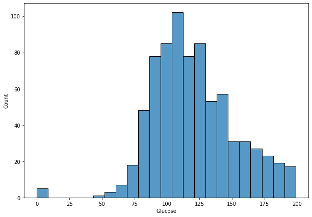

```python
plt.figure(figsize=(10,7))
sns.histplot(df["Glucose"])
```

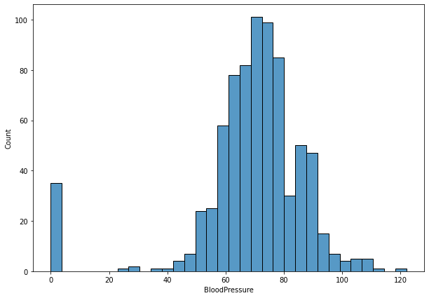

```python
plt.figure(figsize=(10,7))
sns.histplot(df["BloodPressure"])
```

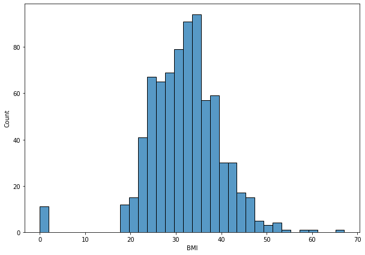

```python
plt.figure(figsize=(10,7))
sns.histplot(df["BMI"])
```

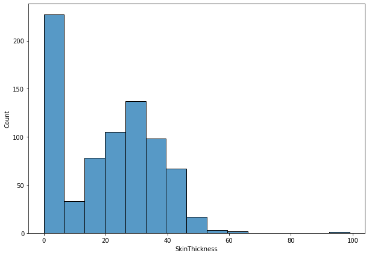

```python
plt.figure(figsize=(10,7))
sns.histplot(df["SkinThickness"])
```

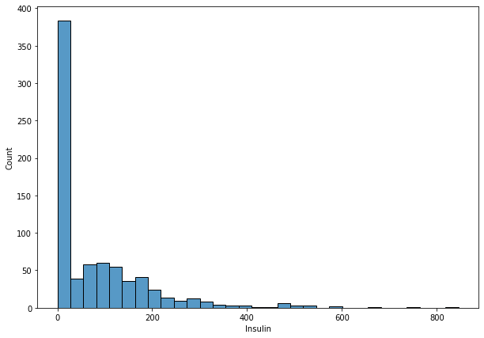

```python
plt.figure(figsize=(10,7))
sns.histplot(df["Insulin"])
```

```python
df["Glucose"].mean()
```

```
120.89453125
```

### Repalce missing values i.e. 0

```python
df["Glucose"]=df["Glucose"].replace(0,df["Glucose"].median())
df["BMI"]=df["BMI"].replace(0,df["BMI"].mean())
df["BloodPressure"]=df["BloodPressure"].replace(0,df["BloodPressure"].median())
df["Insulin"]=df["Insulin"].replace(0,df["Insulin"].median())
df["SkinThickness"]=df["SkinThickness"].replace(0,df["SkinThickness"].median())
```

```python
df.head()
```

|  | Pregnancies | Glucose | BloodPressure | SkinThickness | Insulin | BMI | DiabetesPedigreeFunction | Age | Outcome |
| --- | --- | --- | --- | --- | --- | --- | --- | --- | --- |
| 0 | 6 | 148 | 72 | 35 | 30.5 | 33.6 | 0.627 | 50 | 1 |
| 1 | 1 | 85 | 66 | 29 | 30.5 | 26.6 | 0.351 | 31 | 0 |
| 2 | 8 | 183 | 64 | 23 | 30.5 | 23.3 | 0.672 | 32 | 1 |
| 3 | 1 | 89 | 66 | 23 | 94.0 | 28.1 | 0.167 | 21 | 0 |
| 4 | 0 | 137 | 40 | 35 | 168.0 | 43.1 | 2.288 | 33 | 1 |

```python
df.tail()
```

|  | Pregnancies | Glucose | BloodPressure | SkinThickness | Insulin | BMI | DiabetesPedigreeFunction | Age | Outcome |
| --- | --- | --- | --- | --- | --- | --- | --- | --- | --- |
| 763 | 10 | 101 | 76 | 48 | 180.0 | 32.9 | 0.171 | 63 | 0 |
| 764 | 2 | 122 | 70 | 27 | 30.5 | 36.8 | 0.340 | 27 | 0 |
| 765 | 5 | 121 | 72 | 23 | 112.0 | 26.2 | 0.245 | 30 | 0 |
| 766 | 1 | 126 | 60 | 23 | 30.5 | 30.1 | 0.349 | 47 | 1 |
| 767 | 1 | 93 | 70 | 31 | 30.5 | 30.4 | 0.315 | 23 | 0 |

### There are integer and float data type variables in this dataset. Create a count (frequency) plot describing the data types and the count of variables

```python
df.dtypes.value_counts()
```

```
int64      6
float64    3
dtype: int64
```

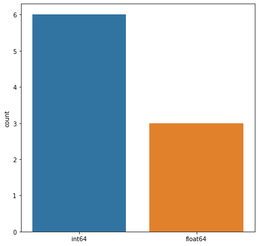

```python
plt.figure(figsize=(7,7))
sns.countplot(df.dtypes)
```

### Check the balance of the data by plotting the count of outcomes by their value. Describe your findings and plan future course of action

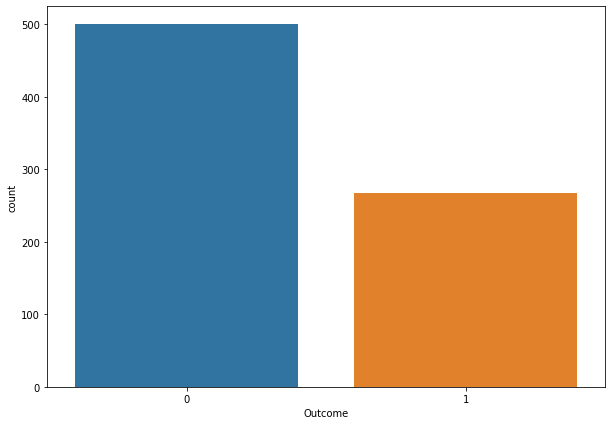

```python
plt.figure(figsize=(10,7))
sns.countplot(df["Outcome"])
```

## Create scatter charts between the pair of variables to understand the relationships

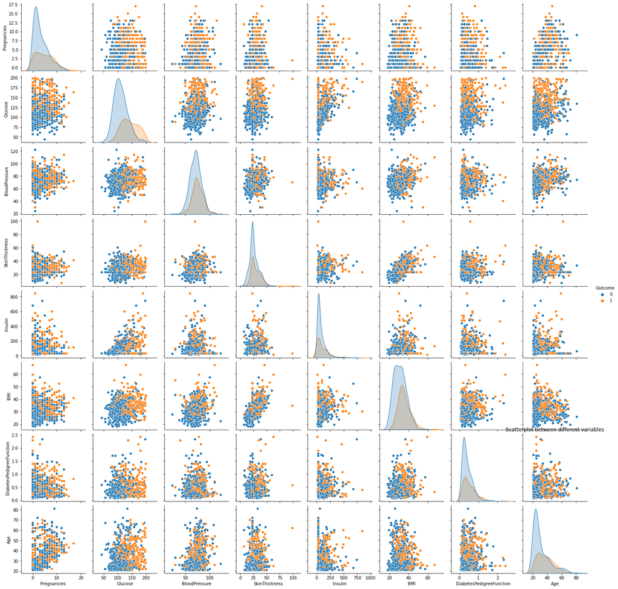

```python
sns.pairplot(data=df,hue="Outcome")
plt.title("Scatterplot between different variables")
```

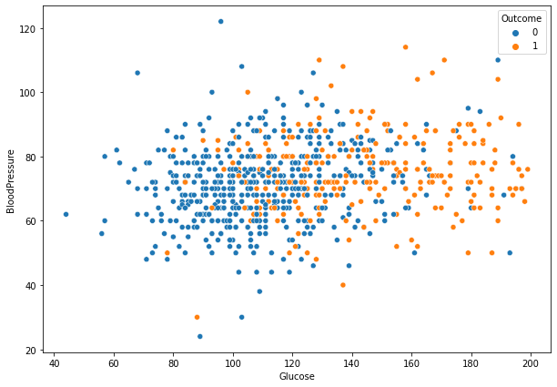

```python
plt.figure(figsize=(10,7))
sns.scatterplot("Glucose","BloodPressure",data=df,hue="Outcome")
```

## Perform correlation analysis. Visually explore it using a heat map

```python
df.corr()
```

|  | Pregnancies | Glucose | BloodPressure | SkinThickness | Insulin | BMI | DiabetesPedigreeFunction | Age | Outcome |
| --- | --- | --- | --- | --- | --- | --- | --- | --- | --- |
| Pregnancies | 1.000000 | 0.128213 | 0.208615 | 0.032568 | -0.055697 | 0.021546 | -0.033523 | 0.544341 | 0.221898 |
| Glucose | 0.128213 | 1.000000 | 0.218937 | 0.172143 | 0.357573 | 0.231408 | 0.137327 | 0.266909 | 0.492782 |
| BloodPressure | 0.208615 | 0.218937 | 1.000000 | 0.147809 | -0.028721 | 0.281129 | -0.002378 | 0.324915 | 0.165723 |
| SkinThickness | 0.032568 | 0.172143 | 0.147809 | 1.000000 | 0.238188 | 0.546958 | 0.142977 | 0.054514 | 0.189065 |
| Insulin | -0.055697 | 0.357573 | -0.028721 | 0.238188 | 1.000000 | 0.189031 | 0.178029 | -0.015413 | 0.148457 |
| BMI | 0.021546 | 0.231408 | 0.281129 | 0.546958 | 0.189031 | 1.000000 | 0.153508 | 0.025748 | 0.312254 |
| DiabetesPedigreeFunction | -0.033523 | 0.137327 | -0.002378 | 0.142977 | 0.178029 | 0.153508 | 1.000000 | 0.033561 | 0.173844 |
| Age | 0.544341 | 0.266909 | 0.324915 | 0.054514 | -0.015413 | 0.025748 | 0.033561 | 1.000000 | 0.238356 |
| Outcome | 0.221898 | 0.492782 | 0.165723 | 0.189065 | 0.148457 | 0.312254 | 0.173844 | 0.238356 | 1.000000 |

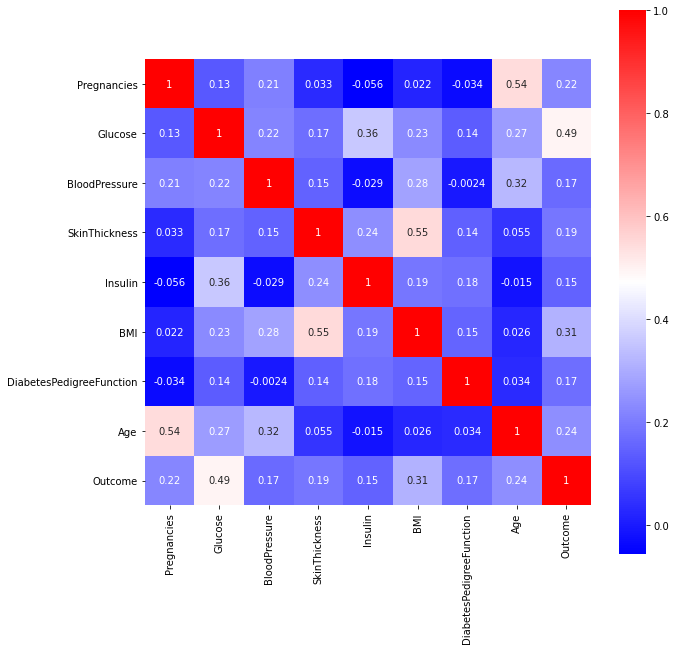

```python
plt.figure(figsize=(10,10))
sns.heatmap(df.corr(),cmap="bwr",square=True,annot=True)
```

## Project Task: Week 2(Data modeling)

1.Devise strategies for model building. It is important to decide the right validation framework. Express your thought process.

2.Apply an appropriate classification algorithm to build a model.

3.Compare various models with the results from KNN algorithm.

4.Create a classification report by analyzing sensitivity, specificity, AUC (ROC curve), etc.

```python
df.head()
```

|  | Pregnancies | Glucose | BloodPressure | SkinThickness | Insulin | BMI | DiabetesPedigreeFunction | Age | Outcome |
| --- | --- | --- | --- | --- | --- | --- | --- | --- | --- |
| 0 | 6 | 148 | 72 | 35 | 30.5 | 33.6 | 0.627 | 50 | 1 |
| 1 | 1 | 85 | 66 | 29 | 30.5 | 26.6 | 0.351 | 31 | 0 |
| 2 | 8 | 183 | 64 | 23 | 30.5 | 23.3 | 0.672 | 32 | 1 |
| 3 | 1 | 89 | 66 | 23 | 94.0 | 28.1 | 0.167 | 21 | 0 |
| 4 | 0 | 137 | 40 | 35 | 168.0 | 43.1 | 2.288 | 33 | 1 |

```python
x=df.drop("Outcome",axis=1)
y=df[["Outcome"]]
```

```python
x.head()
```

|  | Pregnancies | Glucose | BloodPressure | SkinThickness | Insulin | BMI | DiabetesPedigreeFunction | Age |
| --- | --- | --- | --- | --- | --- | --- | --- | --- |
| 0 | 6 | 148 | 72 | 35 | 30.5 | 33.6 | 0.627 | 50 |
| 1 | 1 | 85 | 66 | 29 | 30.5 | 26.6 | 0.351 | 31 |
| 2 | 8 | 183 | 64 | 23 | 30.5 | 23.3 | 0.672 | 32 |
| 3 | 1 | 89 | 66 | 23 | 94.0 | 28.1 | 0.167 | 21 |
| 4 | 0 | 137 | 40 | 35 | 168.0 | 43.1 | 2.288 | 33 |

```python
y.head()
```

|  | Outcome |
| --- | --- |
| 0 | 1 |
| 1 | 0 |
| 2 | 1 |
| 3 | 0 |
| 4 | 1 |

```python
from sklearn.model_selection import train_test_split
```

```python
x_train,x_test,y_train,y_test=train_test_split(x,y,test_size=0.25,random_state=25)
```

```python
x_train.shape,x_test.shape
```

```
((576, 8), (192, 8))
```

```python
y_train.shape,y_test.shape
```

```
((576, 1), (192, 1))
```

```python
x_train.head()
```

|  | Pregnancies | Glucose | BloodPressure | SkinThickness | Insulin | BMI | DiabetesPedigreeFunction | Age |
| --- | --- | --- | --- | --- | --- | --- | --- | --- |
| 427 | 1 | 181 | 64 | 30 | 180.0 | 34.1 | 0.328 | 38 |
| 133 | 8 | 84 | 74 | 31 | 30.5 | 38.3 | 0.457 | 39 |
| 262 | 4 | 95 | 70 | 32 | 30.5 | 32.1 | 0.612 | 24 |
| 358 | 12 | 88 | 74 | 40 | 54.0 | 35.3 | 0.378 | 48 |
| 489 | 8 | 194 | 80 | 23 | 30.5 | 26.1 | 0.551 | 67 |

```python
from sklearn.preprocessing import StandardScaler
```

```python
scaler=StandardScaler()
x_train=scaler.fit_transform(x_train)
x_test=scaler.transform(x_test)
```

```python
x_train
```

```
array([[-0.82827947,  1.9049318 , -0.72994462, ...,  0.2534439 ,
        -0.42508999,  0.37784439],
       [ 1.24216246, -1.24181301,  0.10494041, ...,  0.86654809,
        -0.0415753 ,  0.46339407],
       [ 0.05905278, -0.88496566, -0.2290136 , ..., -0.03851047,
         0.41923693, -0.81985104],
       ...,
       [ 0.05905278, -0.26859296, -0.72994462, ..., -0.50563747,
        -1.02563238, -0.81985104],
       [-0.23672464, -0.23615229, -0.56296761, ...,  0.83735265,
        -0.95428081, -0.47765234],
       [-0.23672464,  1.54808445, -0.72994462, ...,  0.31183478,
        -0.34184649, -0.306553  ]])
```

## Logistic regression

```python
from sklearn.linear_model import LogisticRegression
```

```python
log_model=LogisticRegression()
log_model.fit(x_train,y_train)
```

```
LogisticRegression()
```

```python
log_pred=log_model.predict(x_test)
log_pred
```

```
array([1, 0, 0, 1, 0, 0, 0, 0, 0, 0, 1, 0, 0, 1, 0, 1, 0, 0, 0, 0, 0, 0,
       0, 0, 0, 0, 0, 1, 0, 0, 0, 1, 0, 1, 1, 0, 1, 0, 0, 0, 0, 0, 1, 0,
       0, 0, 0, 0, 0, 0, 1, 1, 1, 0, 1, 0, 1, 0, 0, 0, 0, 0, 0, 0, 0, 1,
       0, 1, 0, 0, 0, 1, 0, 0, 1, 0, 1, 1, 0, 0, 0, 0, 1, 1, 0, 0, 1, 1,
       0, 0, 0, 0, 0, 0, 0, 0, 0, 0, 0, 0, 1, 0, 0, 1, 0, 0, 0, 0, 1, 1,
       1, 1, 0, 0, 0, 1, 0, 1, 0, 0, 0, 0, 0, 1, 0, 0, 1, 0, 0, 1, 0, 0,
       0, 0, 0, 0, 0, 0, 0, 0, 1, 0, 1, 0, 0, 1, 0, 0, 0, 0, 1, 0, 1, 0,
       0, 0, 0, 0, 1, 1, 0, 0, 1, 0, 0, 1, 0, 0, 0, 0, 0, 0, 1, 0, 0, 0,
       0, 1, 0, 1, 1, 0, 0, 0, 1, 0, 0, 1, 1, 0, 0, 1], dtype=int64)
```

```python
from sklearn.metrics import accuracy_score,confusion_matrix,classification_report,roc_curve,auc,RocCurveDisplay
```

```python
accuracy_score(log_pred,y_test)
```

```
0.8020833333333334
```

```python
accuracy_score(log_model.predict(x_train),y_train)
```

```
0.765625
```

```python
confusion_matrix(log_pred,y_test)
```

```
array([[115,  23],
       [ 15,  39]], dtype=int64)
```

## Specificity=TN/(TN+FP)

```python
print("Sensitivity is ",115/(115+39))
print("Specificity is ",23/(23+15))
```

```
Sensitivity is  0.7467532467532467
Specificity is  0.6052631578947368
```

```python
print(classification_report(log_pred,y_test))
```

```
              precision    recall  f1-score   support

           0       0.88      0.83      0.86       138
           1       0.63      0.72      0.67        54

    accuracy                           0.80       192
   macro avg       0.76      0.78      0.77       192
weighted avg       0.81      0.80      0.81       192
```

```python
log_model.predict_proba(x_test)
```

[output not shown]

[output cut: 137 more lines]

```
       [0.48860969, 0.51139031],
       [0.6171518 , 0.3828482 ],
       [0.44535515, 0.55464485],
       [0.23443856, 0.76556144],
       [0.74161218, 0.25838782],
       [0.8793028 , 0.1206972 ],
       [0.89664476, 0.10335524],
       [0.18860671, 0.81139329],
       [0.70937628, 0.29062372],
       [0.92169631, 0.07830369],
       [0.33210235, 0.66789765],
       [0.10412118, 0.89587882],
       [0.93956879, 0.06043121],
       [0.5617854 , 0.4382146 ],
       [0.04899981, 0.95100019]])
```

```python
log_pred_proba=log_model.predict_proba(x_test)[:,1]
log_pred_proba
```

[output not shown]

```python
fpr,tpr,thresholds=roc_curve(y_test,log_pred_proba)
print(fpr)
print("\n")
print(tpr)
print("\n")
print(thresholds)
```

```
[0.         0.         0.00769231 0.00769231 0.03076923 0.03076923
 0.03846154 0.03846154 0.05384615 0.05384615 0.06153846 0.06153846
 0.08461538 0.08461538 0.1        0.1        0.10769231 0.10769231
 0.11538462 0.11538462 0.16923077 0.16923077 0.17692308 0.17692308
 0.20769231 0.20769231 0.23076923 0.23076923 0.25384615 0.25384615
 0.28461538 0.28461538 0.29230769 0.29230769 0.36923077 0.36923077
 0.56923077 0.56923077 0.57692308 0.57692308 0.6        0.6
 0.62307692 0.62307692 0.63846154 0.63846154 0.66153846 0.66153846
 0.88461538 0.88461538 1.        ]


[0.         0.01612903 0.01612903 0.20967742 0.20967742 0.32258065
 0.32258065 0.43548387 0.43548387 0.48387097 0.48387097 0.51612903
 0.51612903 0.56451613 0.56451613 0.58064516 0.58064516 0.61290323
 0.61290323 0.66129032 0.66129032 0.69354839 0.69354839 0.72580645
 0.72580645 0.74193548 0.74193548 0.79032258 0.79032258 0.80645161
 0.80645161 0.82258065 0.82258065 0.85483871 0.85483871 0.87096774
 0.87096774 0.88709677 0.88709677 0.91935484 0.91935484 0.93548387
 0.93548387 0.9516129  0.9516129  0.96774194 0.96774194 0.98387097
 0.98387097 1.         1.        ]


[1.95100019 0.95100019 0.93072722 0.83115571 0.81012187 0.76229796
 0.76197806 0.69116744 0.66789765 0.66542886 0.66189979 0.64943303
 0.62773213 0.5675451  0.54688089 0.5345092  0.52360011 0.51139031
 0.50281936 0.48053339 0.42851411 0.41804635 0.39402362 0.38863172
 0.36349778 0.35598562 0.33449819 0.33207264 0.31283352 0.31275954
 0.29774718 0.29104723 0.29062372 0.29005887 0.26013069 0.25838782
 0.16563467 0.16496116 0.16476691 0.1636917  0.1544139  0.15232222
 0.14300402 0.14024012 0.13493239 0.13197548 0.12855523 0.12798207
 0.06240331 0.0612825  0.01325235]
```

```python
roc_auc=auc(fpr,tpr)
roc_auc
```

```
0.8388337468982631
```

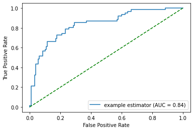

```python
display=RocCurveDisplay(fpr=fpr,tpr=tpr,roc_auc=roc_auc,estimator_name="example estimator")
display.plot()
plt.plot(fpr,fpr,"r--",color="green")
```